# Pandas and StatModels

Includes material from:

- http://statsmodels.sourceforge.net/stable/index.html.
- *Python for Data Analysis* by Wes McKinney, O'Reilly, 2013.
- *Think Stats: Exploratory Data Analysis with Python* by Allen B. Downey, O'Reilly, 2014.

> Panos Louridas, Associate Professor  
> Department of Management Science and Technology  
> Athens University of Economics and Business  
> louridas@aueb.gr

# The Guerry DataSet

- The Guerry dataset, a collection of historical data used in support of Andre-Michel Guerry’s 1833 Essay on the Moral Statistics of France.
- The data set is hosted online in comma-separated values format (CSV) by the Rdatasets repository.
- We could download the file locally and then load it using `pd.read_csv`, but StatsModels can take of all of this automatically for us.

```python
import numpy as np
import pandas as pd
import statsmodels.api as sm
from patsy import dmatrices

df = sm.datasets.get_rdataset("Guerry", "HistData").data
```

- We select the variables of interest and look at the bottom 5 rows.

```python
vars = ['Department', 'Lottery', 'Literacy', 'Wealth', 'Region']

df = df[vars]
df[-5:]
```

|  | Department | Lottery | Literacy | Wealth | Region |
| --- | --- | --- | --- | --- | --- |
| 81 | Vienne | 40 | 25 | 68 | W |
| 82 | Haute-Vienne | 55 | 13 | 67 | C |
| 83 | Vosges | 14 | 62 | 82 | E |
| 84 | Yonne | 51 | 47 | 30 | C |
| 85 | Corse | 83 | 49 | 37 | NaN |

- Notice that there is one missing observation in the Region column.
- We eliminate it using using the `DataFrame.dropna()` method.

```python
df = df.dropna()
df[-5:]
```

|  | Department | Lottery | Literacy | Wealth | Region |
| --- | --- | --- | --- | --- | --- |
| 80 | Vendee | 68 | 28 | 56 | W |
| 81 | Vienne | 40 | 25 | 68 | W |
| 82 | Haute-Vienne | 55 | 13 | 67 | C |
| 83 | Vosges | 14 | 62 | 82 | E |
| 84 | Yonne | 51 | 47 | 30 | C |

- We want to know whether literacy rates in the 86 French departments are associated with per capita wagers on the Royal Lottery in the 1820s.
- We need to control for the level of wealth in each department, and we also want to include a series of dummy variables on the right-hand side of our regression equation to control for unobserved heterogeneity due to regional effects.
- The model is estimated using ordinary least squares regression (OLS).

# Design Matrices

- A regression model, written in matrix-vector form is $$y=X\beta +\epsilon$$
- The matrix $X$ is the design matrix
- $y$ is the vector of observations on the dependent variable
- $\beta$ is a vector of response coefficients (one for each explanatory variable)
- $\epsilon$ is a vector containing the values of the model's error term for the various observations.
- In the design matrix, each column is a vector of observations on one of the explanatory variables.

# Simple Regression Design Matrices

- If we have seven data points, $(x_i, y_i)$ for $i = 1, 2, \ldots 7$ then the regression model is:

$$y_{i}=\beta _{0}+\beta _{1}x_{i}+\epsilon _{i}$$

- The model can be represented in matrix form as:

$$ \begin{bmatrix} y_{1}\\y_{2}\\y_{3}\\y_{4}\\y_{5}\\y_{6}\\y_{7} \end{bmatrix} = \begin{bmatrix} 1 & x_{1}\\ 1 & x_{2}\\ 1 & x_{3}\\ 1 & x_{4}\\ 1 & x_{5}\\1 & x_{6}\\1 & x_{7} \end{bmatrix} \begin{bmatrix} \beta_{0}\\ \beta_{1} \end{bmatrix} + \begin{bmatrix} \epsilon_{1}\\ \epsilon_{2}\\ \epsilon_{3}\\ \epsilon_{4}\\ \epsilon_{5}\\ \epsilon_{6}\\ \epsilon_{7} \end{bmatrix} $$

# Multiple Regression Design Matrices

- If we have seven data points, $(x_i, y_i)$ for $i = 1, 2, \ldots 7$ then the regression model is:

$$y_{i}=\beta _{0}+\beta _{1}w_{i}+\beta _{2}x_{i}+\epsilon _{i}$$

- The model can be represented in matrix form as:

$$ \begin{bmatrix} y_{1}\\y_{2}\\y_{3}\\y_{4}\\y_{5}\\y_{6}\\y_{7} \end{bmatrix} = \begin{bmatrix} 1 & w_{1} & x_{1}\\ 1 & w_{2} & x_{2}\\ 1 & w_{3} & x_{3}\\ 1 & w_{4} & x_{4}\\ 1 & w_{5} & x_{5}\\1 & w_{6} & x_{6}\\1 & w_{7} & x_{7} \end{bmatrix} \begin{bmatrix} \beta_{0}\\ \beta_{1}\\ \beta_{2} \end{bmatrix} + \begin{bmatrix} \epsilon_{1}\\ \epsilon_{2}\\ \epsilon_{3}\\ \epsilon_{4}\\ \epsilon_{5}\\ \epsilon_{6}\\ \epsilon_{7} \end{bmatrix} $$

# StatsModels Design Matrices

- In StatsModels, we work with two design matrices.
- The first is a matrix of endogenous variable(s) (i.e. dependent, response, regressand, etc.).
- The second is a matrix of exogenous variable(s) (i.e. independent, predictor, regressor, etc.).

```python
y, X = dmatrices('Lottery ~ Literacy + Wealth + Region', data=df, return_type='dataframe')

y[:3]
```

|  | Lottery |
| --- | --- |
| 0 | 41.0 |
| 1 | 38.0 |
| 2 | 66.0 |

```python
X[:3]
```

|  | Intercept | Region[T.E] | Region[T.N] | Region[T.S] | Region[T.W] | Literacy | Wealth |
| --- | --- | --- | --- | --- | --- | --- | --- |
| 0 | 1.0 | 1.0 | 0.0 | 0.0 | 0.0 | 37.0 | 73.0 |
| 1 | 1.0 | 0.0 | 1.0 | 0.0 | 0.0 | 51.0 | 22.0 |
| 2 | 1.0 | 0.0 | 0.0 | 0.0 | 0.0 | 13.0 | 61.0 |

`dmatrices` has:

- split the categorical Region variable into a set of indicator variables.
- added a constant to the exogenous regressors matrix.
- returned pandas `DataFrames` instead of simple numpy arrays.

# Model Fitting

- We will use the model class to describe the model.
- Then we will fit the model using the `fit` method.
- And then we will inspect the results using the `summary` method.

```python
mod = sm.OLS(y, X)    # Describe model

res = mod.fit()       # Fit model

res.summary()   # Summarize model
```

OLS Regression Results

| Dep. Variable: | Lottery | R-squared: | 0.338 |
| --- | --- | --- | --- |
| Model: | OLS | Adj. R-squared: | 0.287 |
| Method: | Least Squares | F-statistic: | 6.636 |
| Date: | Thu, 10 Nov 2016 | Prob (F-statistic): | 1.07e-05 |
| Time: | 17:24:32 | Log-Likelihood: | -375.30 |
| No. Observations: | 85 | AIC: | 764.6 |
| Df Residuals: | 78 | BIC: | 781.7 |
| Df Model: | 6 |  |  |
| Covariance Type: | nonrobust |  |  |

|  | coef | std err | t | P>\|t\| | [95.0% Conf. Int.] |
| --- | --- | --- | --- | --- | --- |
| Intercept | 38.6517 | 9.456 | 4.087 | 0.000 | 19.826 57.478 |
| Region[T.E] | -15.4278 | 9.727 | -1.586 | 0.117 | -34.793 3.938 |
| Region[T.N] | -10.0170 | 9.260 | -1.082 | 0.283 | -28.453 8.419 |
| Region[T.S] | -4.5483 | 7.279 | -0.625 | 0.534 | -19.039 9.943 |
| Region[T.W] | -10.0913 | 7.196 | -1.402 | 0.165 | -24.418 4.235 |
| Literacy | -0.1858 | 0.210 | -0.886 | 0.378 | -0.603 0.232 |
| Wealth | 0.4515 | 0.103 | 4.390 | 0.000 | 0.247 0.656 |

| Omnibus: | 3.049 | Durbin-Watson: | 1.785 |
| --- | --- | --- | --- |
| Prob(Omnibus): | 0.218 | Jarque-Bera (JB): | 2.694 |
| Skew: | -0.340 | Prob(JB): | 0.260 |
| Kurtosis: | 2.454 | Cond. No. | 371. |

The `res` object has many useful attributes.

- For example, we can extract parameter estimates and $R^2$.

```python
 res.params
```

```
Intercept      38.651655
Region[T.E]   -15.427785
Region[T.N]   -10.016961
Region[T.S]    -4.548257
Region[T.W]   -10.091276
Literacy       -0.185819
Wealth          0.451475
dtype: float64
```

```python
res.rsquared
```

```
0.3379508691928822
```

# Diagnostics and Specifications Tests

- StatsModels allows you to conduct a range of useful regression diagnostics and specification tests.
- For instance, we can apply the Rainbow test for linearity (the null hypothesis is that the relationship is properly modelled as linear).

```python
sm.stats.linear_rainbow(res)
```

```
(0.84723399761569096, 0.69979655436216437)
```

- The first number is an F-statistic and that the second is the p-value.
- To know this, we either read the online documentation or print the docstring of the function.

```python
print(sm.stats.linear_rainbow.__doc__)
```

```
Rainbow test for linearity

    The Null hypothesis is that the regression is correctly modelled as linear.
    The alternative for which the power might be large are convex, check

    Parameters
    ----------
    res : Result instance

    Returns
    -------
    fstat : float
        test statistic based of F test
    pvalue : float
        pvalue of the test
```

# OLS regression using formulas

- We can also work with StatsModels using R-style formulas.
- This is done thanks to the `patsy` package that we imported back in the beginning.

```python
import statsmodels.formula.api as smf

mod = smf.ols(formula='Lottery ~ Literacy + Wealth + Region', data=df)
res = mod.fit()

res.summary()
```

OLS Regression Results

| Dep. Variable: | Lottery | R-squared: | 0.338 |
| --- | --- | --- | --- |
| Model: | OLS | Adj. R-squared: | 0.287 |
| Method: | Least Squares | F-statistic: | 6.636 |
| Date: | Thu, 10 Nov 2016 | Prob (F-statistic): | 1.07e-05 |
| Time: | 17:24:32 | Log-Likelihood: | -375.30 |
| No. Observations: | 85 | AIC: | 764.6 |
| Df Residuals: | 78 | BIC: | 781.7 |
| Df Model: | 6 |  |  |
| Covariance Type: | nonrobust |  |  |

|  | coef | std err | t | P>\|t\| | [95.0% Conf. Int.] |
| --- | --- | --- | --- | --- | --- |
| Intercept | 38.6517 | 9.456 | 4.087 | 0.000 | 19.826 57.478 |
| Region[T.E] | -15.4278 | 9.727 | -1.586 | 0.117 | -34.793 3.938 |
| Region[T.N] | -10.0170 | 9.260 | -1.082 | 0.283 | -28.453 8.419 |
| Region[T.S] | -4.5483 | 7.279 | -0.625 | 0.534 | -19.039 9.943 |
| Region[T.W] | -10.0913 | 7.196 | -1.402 | 0.165 | -24.418 4.235 |
| Literacy | -0.1858 | 0.210 | -0.886 | 0.378 | -0.603 0.232 |
| Wealth | 0.4515 | 0.103 | 4.390 | 0.000 | 0.247 0.656 |

| Omnibus: | 3.049 | Durbin-Watson: | 1.785 |
| --- | --- | --- | --- |
| Prob(Omnibus): | 0.218 | Jarque-Bera (JB): | 2.694 |
| Skew: | -0.340 | Prob(JB): | 0.260 |
| Kurtosis: | 2.454 | Cond. No. | 371. |

# Categorical variables

- Notice that `patsy` determined that elements of Region were text strings, so it treated Region as a categorical variable.
- If a categorical variable has $L$ distinct values (or levels), then `patsy` by default creates $L - 1$ *dummy* variables.
- Why $L - 1$? Because if we know the values of the $L - 1$ dummy variable then we also know the value of the missing dummy variable. So including $L$ distinct values would overspecify the model.
- This is called *treatment* coding. There are also other coding schemes available:
  - backward difference coding
  - orthogonal polynomial contrast coding
  - deviation coding (also known as sum-to-zero coding)
  - Helmert contrasts coding
- Suppose we have one categorical variable, with two levels.
- Then we will create *one* dummy variable.
- For example, if the categorical variable distinguishes between males and females, we will have:

$$ x_i = \begin{cases} 1 &\text{if the } i\text{th person is female} \\ 0 &\mbox{if the } i\text{th person is male} \\ \end{cases} $$

- Then the model will be:

$$ y_i = \beta_0 + \beta_{1}x_i + \epsilon_i = \begin{cases} \beta_0 + \beta_1 + \epsilon_1 &\text{if the } i\text{th person is female} \\ \beta_0 + \epsilon_1 &\text{if the } i\text{th person is male} \\ \end{cases} $$

- Which means that:
  - $\beta_0$ can be interpreted as the average among males
  - $\beta_0 + \beta_1$ as the average among females
  - $\beta_1$ as the average difference between females and males

# Removing Variables

- The `-` sign can be used to remove columns/variables.
- So we can remove the intercept from a model as follows.
- Observe that removing the intercept will introduce another dummy variable, since they must add up to 1.

```python
res = smf.ols(formula='Lottery ~ Literacy + Wealth + Region -1 ', data=df).fit()
print(res.params)
```

```
Region[C]    38.651655
Region[E]    23.223870
Region[N]    28.634694
Region[S]    34.103399
Region[W]    28.560379
Literacy     -0.185819
Wealth        0.451475
dtype: float64
```

# Multiplicative Interactions

- `:` adds a new column to the design matrix with the product of the other two columns.
- `*` will also include the individual columns that were multiplied together.

```python
res1 = smf.ols(formula='Lottery ~ Literacy : Wealth - 1', data=df).fit()
res2 = smf.ols(formula='Lottery ~ Literacy * Wealth - 1', data=df).fit()
print(res1.params),
print()
print(res2.params)
```

```
Literacy:Wealth    0.018176
dtype: float64

Literacy           0.427386
Wealth             1.080987
Literacy:Wealth   -0.013609
dtype: float64
```

# Functions

- We can apply vectorized functions to the variables in our model.

```python
res = smf.ols(formula='Lottery ~ np.log(Literacy)', data=df).fit()
print(res.params)
```

```
Intercept           115.609119
np.log(Literacy)    -20.393959
dtype: float64
```

- We can also define custom functions.

```python
def log_plus_1(x):
    return np.log(x) + 1.
res = smf.ols(formula='Lottery ~ log_plus_1(Literacy)', data=df).fit()
print(res.params)
```

```
Intercept               136.003079
log_plus_1(Literacy)    -20.393959
dtype: float64
```

# Analysis of Variance (ANOVA)

- For a short example on Two-Way ANOVA, we'll use the Moore dataset.
- The Moore dataset has 45 rows and 4 columns.
- The data are for subjects in a social-psychological experiment, who were faced with manipulated disagreement from a partner of either of low or high status.
- The subjects could either conform to the partner’s judgment or stick with their own judgment.
- Authoritarianism is measured using the F -scale personality test (https://en.wikipedia.org/wiki/F-scale_(personality_test)).
- The test was designed in 1947 by Theodor W. Adorno.
- "F" stands for "fascist".
- `partner.status`: Partner’s status. A factor with levels: high, low.
- `conformity`: Number of conforming responses in 40 critical trials.
- `fcategory`: F-Scale Categorized. A factor with levels (note levels out of order): high, low, medium.
- `fscore`: Authoritarianism: F-Scale score.

```python
moore = sm.datasets.get_rdataset("Moore", "car", cache=True)
data = moore.data
data.head(5)
```

|  | partner.status | conformity | fcategory | fscore |
| --- | --- | --- | --- | --- |
| 0 | low | 8 | low | 37 |
| 1 | low | 4 | high | 57 |
| 2 | low | 8 | high | 65 |
| 3 | low | 7 | low | 20 |
| 4 | low | 10 | low | 36 |

- First, let's make the `partner.status` name pythonic.

```python
data = data.rename(columns={"partner.status": "partner_status"}) # make name pythonic
```

- Then, we create our model.

```python
moore_lm = smf.ols('conformity ~ C(fcategory, Sum) * C(partner_status, Sum)', data=data).fit()
```

- And now we can run our Two-Way ANOVA.

```python
table = sm.stats.anova_lm(moore_lm, typ=2) # type 2 ANOVA
table
```

|  | sum_sq | df | F | PR(>F) |
| --- | --- | --- | --- | --- |
| C(fcategory, Sum) | 11.614700 | 2.0 | 0.276958 | 0.759564 |
| C(partner_status, Sum) | 212.213778 | 1.0 | 10.120692 | 0.002874 |
| C(fcategory, Sum):C(partner_status, Sum) | 175.488928 | 2.0 | 4.184623 | 0.022572 |
| Residual | 817.763961 | 39.0 | NaN | NaN |

# Time Series Basics

- The most basic kind of time series object in pandas is a `Series` indexed by timestamps
- Theseare often represented external to pandas as Python strings or datetime objects.

```python
from datetime import datetime

dates = [datetime(2011, 1, 2), datetime(2011, 1, 5), datetime(2011, 1, 7),
         datetime(2011, 1, 8), datetime(2011, 1, 10), datetime(2011, 1, 12)]

ts = pd.Series(np.random.randn(6), index=dates)

ts
```

```
2011-01-02    2.514152
2011-01-05   -0.895879
2011-01-07   -0.376237
2011-01-08    0.168993
2011-01-10   -1.116665
2011-01-12    0.718023
dtype: float64
```

- Under the hood, these `datetime` objects have been put in a `DatetimeIndex`.

```python
ts.index
```

```
DatetimeIndex(['2011-01-02', '2011-01-05', '2011-01-07', '2011-01-08',
               '2011-01-10', '2011-01-12'],
              dtype='datetime64[ns]', freq=None)
```

- Indexing and selecting works as expected.

```python
stamp = ts.index[2]
ts[stamp]
```

```
-0.37623693936753549
```

- As a convenience, you can also pass a string that is interpretable as a date.

```python
print(ts['1/10/2011']) # notice the american mm/dd date convention!
print()
print(ts['20110110'])
```

```
-1.11666463035

-1.11666463035
```

- For longer time series, a year or only a year and month can be passed to easily select slices of data.

```python
longer_ts = pd.Series(np.random.randn(1000), index=pd.date_range('1/1/2000', periods=1000))
longer_ts.head(5)
```

```
2000-01-01    0.128765
2000-01-02    0.789562
2000-01-03    0.614006
2000-01-04   -0.359808
2000-01-05   -0.815393
Freq: D, dtype: float64
```

```python
longer_ts['2000'].tail(5)
```

```
2000-12-27    0.019312
2000-12-28    0.016551
2000-12-29   -0.277190
2000-12-30   -0.924606
2000-12-31   -0.201506
Freq: D, dtype: float64
```

```python
longer_ts['2000-03'].head(5)
```

```
2000-03-01    0.059733
2000-03-02   -1.657677
2000-03-03   -1.401218
2000-03-04    0.741715
2000-03-05    0.307934
Freq: D, dtype: float64
```

- Slicing with dates works just like with a regular `Series`.

```python
ts[datetime(2011, 1, 7):]
```

```
2011-01-07   -0.376237
2011-01-08    0.168993
2011-01-10   -1.116665
2011-01-12    0.718023
dtype: float64
```

- Because most time series data is ordered chronologically, we can slice with timestamps not contained in a time series to perform a range query.

```python
print(ts)
ts['2011/1/6':'2011/1/11']
```

```
2011-01-02    2.514152
2011-01-05   -0.895879
2011-01-07   -0.376237
2011-01-08    0.168993
2011-01-10   -1.116665
2011-01-12    0.718023
dtype: float64
```

```
2011-01-07   -0.376237
2011-01-08    0.168993
2011-01-10   -1.116665
dtype: float64
```

- Note also that since this is a form of label indexing, the endpoints *are* included:

```python
ts['2011/1/2':'2011/1/7']
```

```
2011-01-02    2.514152
2011-01-05   -0.895879
2011-01-07   -0.376237
dtype: float64
```

- Generic time series in pandas are assumed to be irregular; that is, they have no fixed frequency.
- For many applications this is sufficient. However, it’s often desirable to work relative to a fixed frequency, such as daily, monthly, or every 15 minutes.
- pandas has a full suite of standard time series frequencies and tools for resampling, inferring frequencies, and generating fixed frequency date ranges.
- For example, let's convert the example to a fixed daily frequency by calling `pd.resample`.

```python
print(ts)
print()
dts = ts.resample('D').pad()
print(dts)
```

```
2011-01-02    2.514152
2011-01-05   -0.895879
2011-01-07   -0.376237
2011-01-08    0.168993
2011-01-10   -1.116665
2011-01-12    0.718023
dtype: float64

2011-01-02    2.514152
2011-01-03    2.514152
2011-01-04    2.514152
2011-01-05   -0.895879
2011-01-06   -0.895879
2011-01-07   -0.376237
2011-01-08    0.168993
2011-01-09    0.168993
2011-01-10   -1.116665
2011-01-11   -1.116665
2011-01-12    0.718023
Freq: D, dtype: float64
```

- We can generate ranges of timestamps with the `pd.date_range` function.

```python
pd.date_range('20150401', '20150601')
```

```
DatetimeIndex(['2015-04-01', '2015-04-02', '2015-04-03', '2015-04-04',
               '2015-04-05', '2015-04-06', '2015-04-07', '2015-04-08',
               '2015-04-09', '2015-04-10', '2015-04-11', '2015-04-12',
               '2015-04-13', '2015-04-14', '2015-04-15', '2015-04-16',
               '2015-04-17', '2015-04-18', '2015-04-19', '2015-04-20',
               '2015-04-21', '2015-04-22', '2015-04-23', '2015-04-24',
               '2015-04-25', '2015-04-26', '2015-04-27', '2015-04-28',
               '2015-04-29', '2015-04-30', '2015-05-01', '2015-05-02',
               '2015-05-03', '2015-05-04', '2015-05-05', '2015-05-06',
               '2015-05-07', '2015-05-08', '2015-05-09', '2015-05-10',
               '2015-05-11', '2015-05-12', '2015-05-13', '2015-05-14',
               '2015-05-15', '2015-05-16', '2015-05-17', '2015-05-18',
               '2015-05-19', '2015-05-20', '2015-05-21', '2015-05-22',
               '2015-05-23', '2015-05-24', '2015-05-25', '2015-05-26',
               '2015-05-27', '2015-05-28', '2015-05-29', '2015-05-30',
               '2015-05-31', '2015-06-01'],
              dtype='datetime64[ns]', freq='D')
```

- By default, date_range generates daily timestamps.
- If we pass only a start or end date, you must pass a number of periods to generate.

```python
pd.date_range(start='20150104', periods=20)
```

```
DatetimeIndex(['2015-01-04', '2015-01-05', '2015-01-06', '2015-01-07',
               '2015-01-08', '2015-01-09', '2015-01-10', '2015-01-11',
               '2015-01-12', '2015-01-13', '2015-01-14', '2015-01-15',
               '2015-01-16', '2015-01-17', '2015-01-18', '2015-01-19',
               '2015-01-20', '2015-01-21', '2015-01-22', '2015-01-23'],
              dtype='datetime64[ns]', freq='D')
```

- *Resampling* refers to the process of converting a time series from one frequency to another.
- Aggregating higher frequency data to lower frequency is called *downsampling*.
- Converting lower frequency to higher frequency is called *upsampling*.

```python
rng = pd.date_range('1/1/2016', periods=100, freq='D')

ts = pd.Series(np.random.randn(len(rng)), index=rng)
ts.head(5)
```

```
2016-01-01    1.076659
2016-01-02    0.341662
2016-01-03   -0.721626
2016-01-04   -0.462690
2016-01-05    0.634861
Freq: D, dtype: float64
```

- We can now resample the time series on a monthly basis, taking the mean of the monthly values.

```python
ts.resample('M').mean()
```

```
2016-01-31   -0.050218
2016-02-29   -0.041342
2016-03-31   -0.141491
2016-04-30    0.308490
Freq: M, dtype: float64
```

# Time Series Analysis of U.S. Economics Data

- StatsModels and pandas offer many tools for Time Series Analysis (TSA).
- We'll start with an example dealing with U.S. macroenonomic data.
- The data covers the period from 1959q1 to 2009q3.
- It is already included in the StatsModels distribution.

```python
dta = sm.datasets.macrodata.load_pandas().data
dta.head(5)
```

|  | year | quarter | realgdp | realcons | realinv | realgovt | realdpi | cpi | m1 | tbilrate | unemp | pop | infl | realint |
| --- | --- | --- | --- | --- | --- | --- | --- | --- | --- | --- | --- | --- | --- | --- |
| 0 | 1959.0 | 1.0 | 2710.349 | 1707.4 | 286.898 | 470.045 | 1886.9 | 28.98 | 139.7 | 2.82 | 5.8 | 177.146 | 0.00 | 0.00 |
| 1 | 1959.0 | 2.0 | 2778.801 | 1733.7 | 310.859 | 481.301 | 1919.7 | 29.15 | 141.7 | 3.08 | 5.1 | 177.830 | 2.34 | 0.74 |
| 2 | 1959.0 | 3.0 | 2775.488 | 1751.8 | 289.226 | 491.260 | 1916.4 | 29.35 | 140.5 | 3.82 | 5.3 | 178.657 | 2.74 | 1.09 |
| 3 | 1959.0 | 4.0 | 2785.204 | 1753.7 | 299.356 | 484.052 | 1931.3 | 29.37 | 140.0 | 4.33 | 5.6 | 179.386 | 0.27 | 4.06 |
| 4 | 1960.0 | 1.0 | 2847.699 | 1770.5 | 331.722 | 462.199 | 1955.5 | 29.54 | 139.6 | 3.50 | 5.2 | 180.007 | 2.31 | 1.19 |

- Right now the index is numeric, so we'll convert it to a date index.
- First, we create an `Index` object.
- An `Index` object is an immutable `ndarray` implementing an ordered, sliceable set. It is the basic object storing axis labels for all pandas objects.

```python
index = pd.Index(sm.tsa.datetools.dates_from_range('1959Q1', '2009Q3'))
print(index)
```

```
DatetimeIndex(['1959-03-31', '1959-06-30', '1959-09-30', '1959-12-31',
               '1960-03-31', '1960-06-30', '1960-09-30', '1960-12-31',
               '1961-03-31', '1961-06-30',
               ...
               '2007-06-30', '2007-09-30', '2007-12-31', '2008-03-31',
               '2008-06-30', '2008-09-30', '2008-12-31', '2009-03-31',
               '2009-06-30', '2009-09-30'],
              dtype='datetime64[ns]', length=203, freq=None)
```

- Now we'll assign the index to our data and remove some columns we do not need.

```python
dta.index = index
del dta['year']
del dta['quarter']
```

- Here are the details of the data we've read.

```python
print(sm.datasets.macrodata.NOTE)
```

```
::
    Number of Observations - 203

    Number of Variables - 14

    Variable name definitions::

        year      - 1959q1 - 2009q3
        quarter   - 1-4
        realgdp   - Real gross domestic product (Bil. of chained 2005 US$,
                    seasonally adjusted annual rate)
        realcons  - Real personal consumption expenditures (Bil. of chained
                    2005 US$, seasonally adjusted annual rate)
        realinv   - Real gross private domestic investment (Bil. of chained
                    2005 US$, seasonally adjusted annual rate)
        realgovt  - Real federal consumption expenditures & gross investment
                    (Bil. of chained 2005 US$, seasonally adjusted annual rate)
        realdpi   - Real private disposable income (Bil. of chained 2005
                    US$, seasonally adjusted annual rate)
        cpi       - End of the quarter consumer price index for all urban
                    consumers: all items (1982-84 = 100, seasonally adjusted).
        m1        - End of the quarter M1 nominal money stock (Seasonally
                    adjusted)
        tbilrate  - Quarterly monthly average of the monthly 3-month
                    treasury bill: secondary market rate
        unemp     - Seasonally adjusted unemployment rate (%)
        pop       - End of the quarter total population: all ages incl. armed
                    forces over seas
        infl      - Inflation rate (ln(cpi_{t}/cpi_{t-1}) * 400)
        realint   - Real interest rate (tbilrate - infl)
```

- Let's see our data now.

```python
dta.head(5)
```

|  | realgdp | realcons | realinv | realgovt | realdpi | cpi | m1 | tbilrate | unemp | pop | infl | realint |
| --- | --- | --- | --- | --- | --- | --- | --- | --- | --- | --- | --- | --- |
| 1959-03-31 | 2710.349 | 1707.4 | 286.898 | 470.045 | 1886.9 | 28.98 | 139.7 | 2.82 | 5.8 | 177.146 | 0.00 | 0.00 |
| 1959-06-30 | 2778.801 | 1733.7 | 310.859 | 481.301 | 1919.7 | 29.15 | 141.7 | 3.08 | 5.1 | 177.830 | 2.34 | 0.74 |
| 1959-09-30 | 2775.488 | 1751.8 | 289.226 | 491.260 | 1916.4 | 29.35 | 140.5 | 3.82 | 5.3 | 178.657 | 2.74 | 1.09 |
| 1959-12-31 | 2785.204 | 1753.7 | 299.356 | 484.052 | 1931.3 | 29.37 | 140.0 | 4.33 | 5.6 | 179.386 | 0.27 | 4.06 |
| 1960-03-31 | 2847.699 | 1770.5 | 331.722 | 462.199 | 1955.5 | 29.54 | 139.6 | 3.50 | 5.2 | 180.007 | 2.31 | 1.19 |

- To begin the analysis, we'll plot the evolution of the real adjusted GDP.

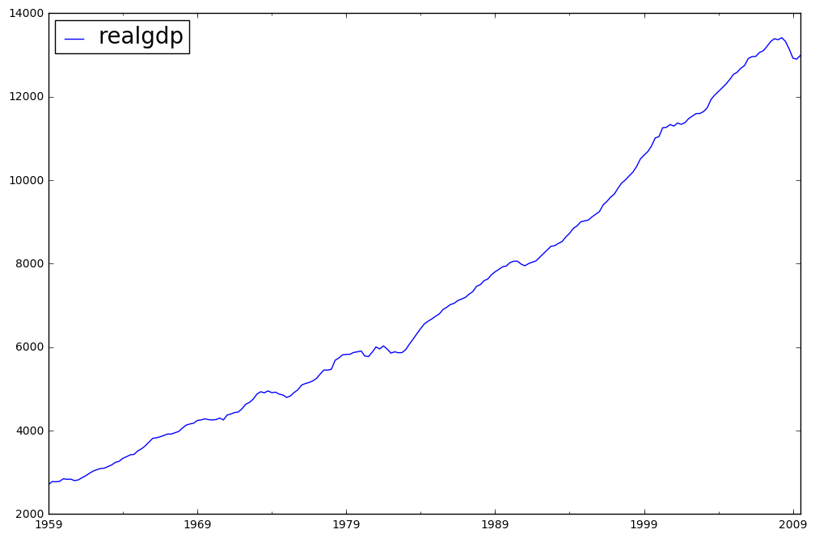

```python
%matplotlib inline

import matplotlib.pyplot as plt

fig = plt.figure(figsize=(12,8))
ax = fig.add_subplot(111)
dta.realgdp.plot(ax=ax)
legend = ax.legend(loc = 'upper left')
legend.prop.set_size(20)
```

# Hodrick-Prescott Filter

- The Hodrick-Prescott filter separates a time-series $y_t$ into a trend $\tau_t$ and a cyclical component $\zeta_t$

$$y_t = \tau_t + \zeta_t$$

- The components are determined by minimizing the following quadratic loss function

$$\min_{\\{ \tau_{t}\\} }\sum_{t}^{T}\zeta_{t}^{2}+\lambda\sum_{t=1}^{T}\left[\left(\tau_{t}-\tau_{t-1}\right)-\left(\tau_{t-1}-\tau_{t-2}\right)\right]^{2}$$

- Fortunately, StatsModels will do the job for us.

```python
gdp_cycle, gdp_trend = sm.tsa.filters.hpfilter(dta.realgdp)
```

- To plot the trend, we'll create a new `DataFrame` with the real GDP, the cycle, and the trend.

```python
gdp_decomp = dta[['realgdp']].copy()
gdp_decomp['cycle'] = gdp_cycle
gdp_decomp['trend'] = gdp_trend
gdp_decomp.head(5)
```

|  | realgdp | cycle | trend |
| --- | --- | --- | --- |
| 1959-03-31 | 2710.349 | 39.511915 | 2670.837085 |
| 1959-06-30 | 2778.801 | 80.088532 | 2698.712468 |
| 1959-09-30 | 2775.488 | 48.875455 | 2726.612545 |
| 1959-12-31 | 2785.204 | 30.591933 | 2754.612067 |
| 1960-03-31 | 2847.699 | 64.882667 | 2782.816333 |

- Then we can plot it.

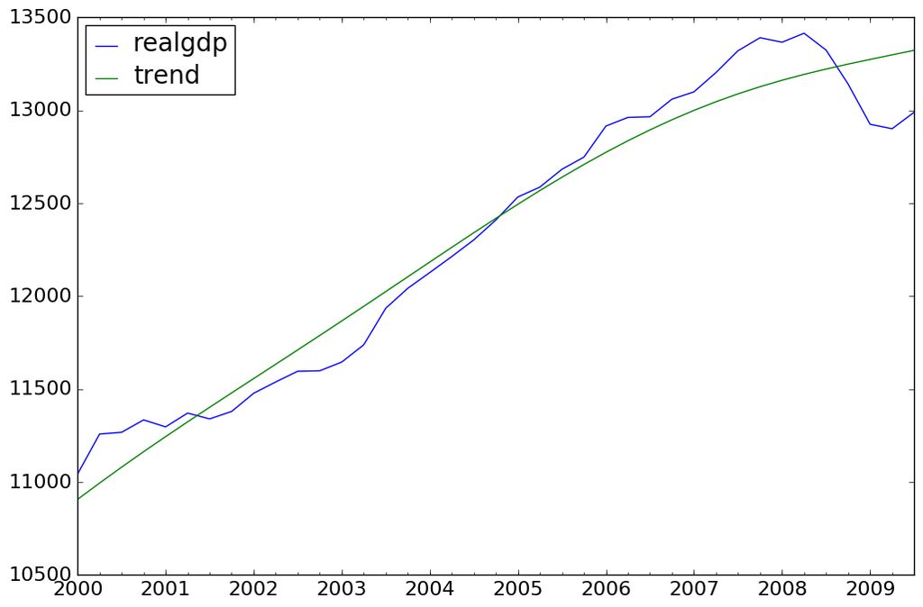

```python
fig = plt.figure(figsize=(12,8))
ax = fig.add_subplot(111)
gdp_decomp[["realgdp", "trend"]]["2000-03-31":].plot(ax=ax, fontsize=16)
legend = ax.get_legend()
legend.prop.set_size(20)
```

# Are Inflation and Unemployment Counter-cyclical?

- To explore whether inflation and unemployment are counter-cyclical, we'll use the Baxter-King filter.
- The Baxter-King filter is intended to explictly deal with the periodicty of the business cycle.
- By applying their band-pass filter to a series, they produce a new series that does not contain fluctuations at higher or lower than those of the business cycle.

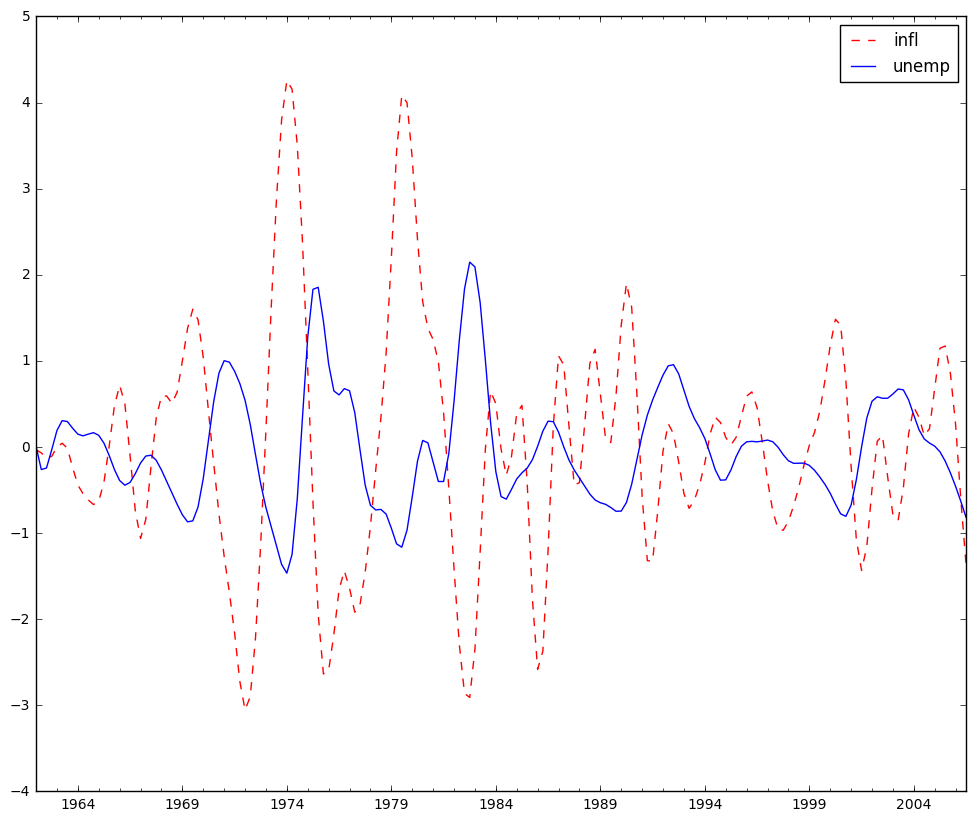

```python
bk_cycles = sm.tsa.filters.bkfilter(dta[["infl","unemp"]])
fig = plt.figure(figsize=(12,10))
ax = fig.add_subplot(111)
bk_cycles.plot(ax=ax, style=['r--', 'b-'])
```

# The National Survey of Family Growth

- Since 1973 the U.S. Centers for Disease Control and Prevention (CDC) have conducted the National Survey of Family Growth (NSFG).
- The dataset is available at http://www.cdc.gov/nchs/nsfg.htm.
- The NSFG is a *cross-sectional* study, which means that it captures a snapshot of a group at a point in time.
- The NSFG has been conducted seven times; each deployment is called a *cycle*. We will use data from Cycle 6, which was conducted from January 2002 to March 2003.
- Pregnancy data from Cycle 6 of the NSFG is in a file called `2002FemPreg.dat.gz`.
- This is a gzip-compressed data file in plain text (ASCII), with fixed width columns.
- Each line in the file is a record that contains data about one pregnancy.

```
           1 1     6 1     11093 1084     9 039 9   0  1 813             1093 13837                        1                5                                                                        116610931166 9201093                111             3    1   12  11         5391 110933316108432411211     2995 1212 69544441116122222 2 2224693215    000000000000000000000000000000000000003410.38939935294273869.3496019830486 6448.2711117047512 91231
```

- The format of the file is documented in `2002FemPreg.dct`, which is a Stata dictionary file.
- Stata is a statistical software system; a "dictionary" in this context is a list of variable names, types, and indices that identify where in each line to find each variable.
- Note that pandas has a function `pd.read_stata`, but that caters for Stata data files, not Stata dictionaries like the one we want to read here.

```
infile dictionary {
    _column(1)      str12                             caseid  %12s  "RESPONDENT ID NUMBER"
   _column(13)       byte                           pregordr   %2f  "PREGNANCY ORDER (NUMBER)"
   _column(15)       byte                          howpreg_n   %2f  "BB-2 # OF WEEKS OR MONTHS CURRENTLY PREGNANT"

...

   _column(34)        int                           cmprgbeg   %4f  "CM FOR PREGNANCY START DATE"

...

  _column(387)      float                            basewgt  %18f  "BASE WEIGHT"
  _column(405)     double                    adj_mod_basewgt  %18f  "ADJUSTED MODIFIED BASE WEIGHT"
  _column(423)     double                           finalwgt  %18f  "FINAL POST-STRATIFIED AND ADJUSTED WEIGHT"

...
    }
```

- We will use a class `FixedWidthVariables` that will be initialized with a `DataFrame` and a number, `index_base`, which will indicate the starting column of interest.
- The input `DataFrame` will contain the start column, the end column, the type, and the string format of the variable in the file.
- We will use that information to create:
  - A list of pairs of (start, end) positions in a line
  - A list of variable names.
- We will feed that to pandas's `read_fwf()` function.

```python
import re
import pandas as pd

class FixedWidthVariables:
    """Represents a set of variables in a fixed width file."""

    def __init__(self, variables, index_base=0):
        """Initializes.
        variables: DataFrame
        index_base: are the indices 0 or 1 based?
        Attributes:
        colspecs: list of (start, end) index tuples
        names: list of string variable names
        """
        self.variables = variables

        # note: by default, subtract 1 from colspecs
        self.colspecs = variables[['start', 'end']] - index_base
        # convert colspecs to a list of pair of int
        self.colspecs = self.colspecs.astype(np.int).values.tolist()
        # assign column names
        self.names = variables['name']

    def read_fixed_width(self, filename, **options):
        """Reads a fixed width ASCII file.
        filename: string filename
        returns: DataFrame
        """
        df = pd.read_fwf(filename, colspecs=self.colspecs, names=self.names, **options)
        return df
```

- Then, we will create a function, `read_stata_dct`, which will read a Stata dictionary file.
- It will return a `FixedWidthVariables` object.

```python
def read_stata_dct(dct_file, **options):
    """Reads a Stata dictionary file.
    dct_file: string filename
    options: dict of options passed to open()
    returns: FixedWidthVariables object
    """
    type_map = dict(byte=int, int=int, long=int, float=float, double=float)

    var_info = []
    for line in open(dct_file, **options):
        match = re.search( r'_column\(([^)]*)\)', line)
        if match:
            start = int(match.group(1))
            t = line.split()
            vtype, name, fstring = t[1:4]
            name = name.lower()
            if vtype.startswith('str'):
                vtype = str
            else:
                vtype = type_map[vtype]
            long_desc = ' '.join(t[4:]).strip('"')
            var_info.append((start, vtype, name, fstring, long_desc))

    columns = ['start', 'type', 'name', 'fstring', 'desc']
    variables = pd.DataFrame(var_info, columns=columns)

    # fill in the end column by shifting the start column
    variables['end'] = variables.start.shift(-1)
    # put a dummy 0 to the last end column of the last row
    variables.loc[len(variables)-1, 'end'] = 0

    dct = FixedWidthVariables(variables, index_base=1)
    return dct
```

- The `variables` `DataFrame` initially has this format:

```
     start             type             name fstring                                          desc
0        1    <class 'str'>           caseid    %12s                          RESPONDENT ID NUMBER
1       13    <class 'int'>         pregordr     %2f                      PREGNANCY ORDER (NUMBER)
2       15    <class 'int'>        howpreg_n     %2f  BB-2 # OF WEEKS OR MONTHS CURRENTLY PREGNANT
```

- Then we add the `end` column by shifting the start column by -1.

```
     start             type             name fstring                                          desc  end
0        1    <class 'str'>           caseid    %12s                          RESPONDENT ID NUMBER   13
1       13    <class 'int'>         pregordr     %2f                      PREGNANCY ORDER (NUMBER)   15
2       15    <class 'int'>        howpreg_n     %2f  BB-2 # OF WEEKS OR MONTHS CURRENTLY PREGNANT   17
```

- We add a dummy 0 in the `end` column of the last row, as it has no value.
- As we explained we will use the `variables` `DataFrame` to read the NSFG data.
- We will use the Pandas `pd.read_fwf()` function that reads fixed-width files.
- The column names will be as in the `name` column of the `variables` `DataFrame`.
- The column specs are pairs of start and end indices for each column.
- We subtract from the `start` and `end` columns the index base

```
self.colspecs = variables[['start', 'end']] - index_base
```

- Then we convert `colspecs` to a `list` of pair of `int`s. We have to convert the type to a Python `int` first, then get the underlying `numpy` object, and convert that to a list.

```
self.colspecs = self.colspecs.astype(np.int).values.tolist()
```

- Finally we assign the column names.

```
self.names = variables['name']
```

- Finally, we need to clean up the data a bit.
- Mother's age is encoded in centiyears (!) therefore we need to convert it to years.
- There are bogus values in the birth weight (> 51 lbs!)
- Replace various "don't know" with NaN.
- Birth weight is broken in lbs and oz, so we need to combine them.

```python
def clean_fem_preg(df):
    """Recodes variables from the pregnancy frame.
    df: DataFrame
    """
    # mother's age is encoded in centiyears; convert to years
    df.agepreg /= 100.0

    # birthwgt_lb contains at least one bogus value (51 lbs)
    # replace with NaN
    df.loc[df.birthwgt_lb > 20, 'birthwgt_lb'] = np.nan

    # replace 'not ascertained', 'refused', 'don't know' with NaN
    na_vals = [97, 98, 99]
    df.birthwgt_lb.replace(na_vals, np.nan, inplace=True)
    df.birthwgt_oz.replace(na_vals, np.nan, inplace=True)
    df.hpagelb.replace(na_vals, np.nan, inplace=True)

    df.babysex.replace([7, 9], np.nan, inplace=True)
    df.nbrnaliv.replace([9], np.nan, inplace=True)

    # birthweight is stored in two columns, lbs and oz.
    # convert to a single column in lb
    # NOTE: creating a new column requires dictionary syntax,
    # not attribute assignment (like df.totalwgt_lb)
    df['totalwgt_lb'] = df.birthwgt_lb + df.birthwgt_oz / 16.0

    # due to a bug in read_stata_dct, the last variable gets clipped;
    # so for now set it to NaN
    df.cmintvw = np.nan
```

- With this machinery in place we can now read the data.

```python
dct_file='2002FemPreg.dct'
dat_file='2002FemPreg.dat.gz'

dct = read_stata_dct(dct_file, encoding='iso-8859-1')
df = dct.read_fixed_width(dat_file, compression='gzip')

clean_fem_preg(df)

preg = df
```

- We'll get the live births, the first births, and the other births.

```python
live = preg[preg.outcome == 1].copy()
firsts = live[live.birthord == 1]
others = live[live.birthord != 1]
```

- Now let's examine the relationship between the total weight and the age of the mother.

```python
formula = 'totalwgt_lb ~ agepreg'
model = smf.ols(formula, data=live)
results = model.fit()
```

- Let's see the intercept and the slope.

```python
inter = results.params['Intercept']
slope = results.params['agepreg']
print('inter =', inter, 'slope =', slope)
```

```
inter = 6.83039697331 slope = 0.0174538514718
```

- `pvalues` is a `Series` that maps from variable names to the associated p-values, so we can check whether the estimated slope is statistically significant:

```python
slope_pvalue = results.pvalues['agepreg']
print(slope_pvalue)
```

```
5.72294710731e-11
```

- `results.rsquared` contains $R^2$.

```python
results.rsquared
```

```
0.0047381154747098142
```

- `results` also provides `f_pvalue`, which is the p-value associated with the model as a whole, similar to testing whether $R^2$ is statistically significant.
- It also provides `resid`, a sequence of residuals, and `fittedvalues`, a sequence of fitted values corresponding to `agepreg`.
- To see everything together, we print the summary.

```python
results.summary()
```

OLS Regression Results

| Dep. Variable: | totalwgt_lb | R-squared: | 0.005 |
| --- | --- | --- | --- |
| Model: | OLS | Adj. R-squared: | 0.005 |
| Method: | Least Squares | F-statistic: | 43.02 |
| Date: | Thu, 10 Nov 2016 | Prob (F-statistic): | 5.72e-11 |
| Time: | 17:24:40 | Log-Likelihood: | -15897. |
| No. Observations: | 9038 | AIC: | 3.180e+04 |
| Df Residuals: | 9036 | BIC: | 3.181e+04 |
| Df Model: | 1 |  |  |
| Covariance Type: | nonrobust |  |  |

|  | coef | std err | t | P>\|t\| | [95.0% Conf. Int.] |
| --- | --- | --- | --- | --- | --- |
| Intercept | 6.8304 | 0.068 | 100.470 | 0.000 | 6.697 6.964 |
| agepreg | 0.0175 | 0.003 | 6.559 | 0.000 | 0.012 0.023 |

| Omnibus: | 1024.052 | Durbin-Watson: | 1.618 |
| --- | --- | --- | --- |
| Prob(Omnibus): | 0.000 | Jarque-Bera (JB): | 3081.833 |
| Skew: | -0.601 | Prob(JB): | 0.00 |
| Kurtosis: | 5.596 | Cond. No. | 118. |

# Multiple Regression

- Birth weight depends on mother's age.
- First babies tend to be lighter than others.
- Could it be because mothers of first babies are younger than others?
- First, let's see how big the difference is.

```python
diff_weight = firsts.totalwgt_lb.mean() - others.totalwgt_lb.mean()
print(diff_weight)
```

```
-0.124761184535
```

- First babies are 0.125 lbs lighter.
- We'll do the same thing with ages.

```python
diff_age = firsts.agepreg.mean() - others.agepreg.mean()
print(diff_age)
```

```
-3.58643476615
```

- The mothers of first babies are 3.59 years younger.
- Running the linear model again, we get the change in birth weight as a function of age.

```python
results = smf.ols('totalwgt_lb ~ agepreg', data=live).fit()
slope = results.params['agepreg']
print(slope)
```

```
0.0174538514718
```

- The slope is 0.0175 pounds per year.
- If we multiply the slope by the difference in ages, we get the expected difference in birth weight for first babies and others, due to mother’s age.

```python
slope * diff_age
```

```
-0.062597099721692515
```

- The result is 0.063, just about half of the observed difference.
- So we conclude, tentatively, that the observed difference in birth weight can be partly explained by the difference in mother’s age.
- But let's check the overall picture.

```python
results.summary()
```

OLS Regression Results

| Dep. Variable: | totalwgt_lb | R-squared: | 0.005 |
| --- | --- | --- | --- |
| Model: | OLS | Adj. R-squared: | 0.005 |
| Method: | Least Squares | F-statistic: | 43.02 |
| Date: | Thu, 10 Nov 2016 | Prob (F-statistic): | 5.72e-11 |
| Time: | 17:24:40 | Log-Likelihood: | -15897. |
| No. Observations: | 9038 | AIC: | 3.180e+04 |
| Df Residuals: | 9036 | BIC: | 3.181e+04 |
| Df Model: | 1 |  |  |
| Covariance Type: | nonrobust |  |  |

|  | coef | std err | t | P>\|t\| | [95.0% Conf. Int.] |
| --- | --- | --- | --- | --- | --- |
| Intercept | 6.8304 | 0.068 | 100.470 | 0.000 | 6.697 6.964 |
| agepreg | 0.0175 | 0.003 | 6.559 | 0.000 | 0.012 0.023 |

| Omnibus: | 1024.052 | Durbin-Watson: | 1.618 |
| --- | --- | --- | --- |
| Prob(Omnibus): | 0.000 | Jarque-Bera (JB): | 3081.833 |
| Skew: | -0.601 | Prob(JB): | 0.00 |
| Kurtosis: | 5.596 | Cond. No. | 118. |

- $R^2$ is 0.005, which is too small.
- That means that `ageprep` does not account for a significant part of the variation in birth weight.
- Let's see what is the picture for the first births

```python
isfirst = live.birthord == 1
live['isfirst'] = isfirst
formula = 'totalwgt_lb ~ isfirst'
results = smf.ols(formula, data=live).fit()
results.summary()
```

OLS Regression Results

| Dep. Variable: | totalwgt_lb | R-squared: | 0.002 |
| --- | --- | --- | --- |
| Model: | OLS | Adj. R-squared: | 0.002 |
| Method: | Least Squares | F-statistic: | 17.74 |
| Date: | Thu, 10 Nov 2016 | Prob (F-statistic): | 2.55e-05 |
| Time: | 17:24:40 | Log-Likelihood: | -15909. |
| No. Observations: | 9038 | AIC: | 3.182e+04 |
| Df Residuals: | 9036 | BIC: | 3.184e+04 |
| Df Model: | 1 |  |  |
| Covariance Type: | nonrobust |  |  |

|  | coef | std err | t | P>\|t\| | [95.0% Conf. Int.] |
| --- | --- | --- | --- | --- | --- |
| Intercept | 7.3259 | 0.021 | 356.007 | 0.000 | 7.286 7.366 |
| isfirst[T.True] | -0.1248 | 0.030 | -4.212 | 0.000 | -0.183 -0.067 |

| Omnibus: | 988.919 | Durbin-Watson: | 1.613 |
| --- | --- | --- | --- |
| Prob(Omnibus): | 0.000 | Jarque-Bera (JB): | 2897.107 |
| Skew: | -0.589 | Prob(JB): | 0.00 |
| Kurtosis: | 5.511 | Cond. No. | 2.58 |

- We see that the intercept is 7.3259.
- $R^2$ is 0.002.
- `isfirst` is a boolean, so `ols` treats it as a *categorical variable*, which means that the values fall into categories, like `True` and `False`, and should not be treated as numbers.
- The estimated parameter is the effect on birth weight when `isfirst` is true, so the result, -0.125 lbs, is the difference in birth weight between first babies and others.
- The slope and the intercept are statistically significant, which means that they were unlikely to occur by chance.
- However, the $R^2$ value for this model is small, which means that `isfirst` doesn’t account for a substantial part of the variation in birth weight.
- What about the two variables taken together?

```python
formula = 'totalwgt_lb ~ isfirst + agepreg'
results = smf.ols(formula, data=live).fit()
results.summary()
```

OLS Regression Results

| Dep. Variable: | totalwgt_lb | R-squared: | 0.005 |
| --- | --- | --- | --- |
| Model: | OLS | Adj. R-squared: | 0.005 |
| Method: | Least Squares | F-statistic: | 24.02 |
| Date: | Thu, 10 Nov 2016 | Prob (F-statistic): | 3.95e-11 |
| Time: | 17:24:40 | Log-Likelihood: | -15894. |
| No. Observations: | 9038 | AIC: | 3.179e+04 |
| Df Residuals: | 9035 | BIC: | 3.182e+04 |
| Df Model: | 2 |  |  |
| Covariance Type: | nonrobust |  |  |

|  | coef | std err | t | P>\|t\| | [95.0% Conf. Int.] |
| --- | --- | --- | --- | --- | --- |
| Intercept | 6.9142 | 0.078 | 89.073 | 0.000 | 6.762 7.066 |
| isfirst[T.True] | -0.0698 | 0.031 | -2.236 | 0.025 | -0.131 -0.009 |
| agepreg | 0.0154 | 0.003 | 5.499 | 0.000 | 0.010 0.021 |

| Omnibus: | 1019.945 | Durbin-Watson: | 1.618 |
| --- | --- | --- | --- |
| Prob(Omnibus): | 0.000 | Jarque-Bera (JB): | 3063.682 |
| Skew: | -0.599 | Prob(JB): | 0.00 |
| Kurtosis: | 5.588 | Cond. No. | 137. |

- In the combined model, the parameter for `isfirst` is smaller by about half, which means that part of the apparent effect of `isfirst` is actually accounted for by `agepreg`.
- The p-value for `isfirst` is about 2.5%, which is on the border of statistical significance.
- $R^2$ for this model is a little higher, which indicates that the two variables together account for more variation in birth weight than either alone (but not by much).

# Logistic Regression

- StatsModels provides an implementation of logistic regression called `logit`, named for the function that converts from probability to log odds.
- To demonstrate its use, we’ll look for variables that affect the sex ratio.
- We'll work with the pregnancies that are longer than 30 weeks.

```python
 longer_prg = live[live.prglngth>30].copy()
```

- `logit` requires the dependent variable to be binary (rather than boolean).
- For this reason we create a new column named boy, using `astype(int)` to convert to binary integers.

```python
 longer_prg['boy'] = (df.babysex==1).astype(int)
```

- Factors that have been found to affect sex ratio include parents’ age, birth order, race, and social status.
- We can use logistic regression to see if these effects appear in the NSFG data.
- We'll start with the mother's age.

```python
model = smf.logit('boy ~ agepreg', data=longer_prg)
results = model.fit()
results.summary()
```

```
Optimization terminated successfully.
         Current function value: 0.693015
         Iterations 3
```

Logit Regression Results

| Dep. Variable: | boy | No. Observations: | 8884 |
| --- | --- | --- | --- |
| Model: | Logit | Df Residuals: | 8882 |
| Method: | MLE | Df Model: | 1 |
| Date: | Thu, 10 Nov 2016 | Pseudo R-squ.: | 6.144e-06 |
| Time: | 17:24:40 | Log-Likelihood: | -6156.7 |
| converged: | True | LL-Null: | -6156.8 |
|  |  | LLR p-value: | 0.7833 |

|  | coef | std err | z | P>\|z\| | [95.0% Conf. Int.] |
| --- | --- | --- | --- | --- | --- |
| Intercept | 0.0058 | 0.098 | 0.059 | 0.953 | -0.185 0.197 |
| agepreg | 0.0010 | 0.004 | 0.275 | 0.783 | -0.006 0.009 |

- The parameter of `agepreg` is positive, which suggests that older mothers are more likely to have boys.
- However, the p-value is 0.783, which means that the apparent effect could easily be due to chance.
- Let's try a model with more explaratory variables.
- Along with mother’s age, we'll include father’s age at birth (`hpagelb`), birth order (`birthord`), and race as a categorical variable.

```python
formula = 'boy ~ agepreg + hpagelb + birthord + C(race)'
model = smf.logit(formula, data=longer_prg)
results = model.fit()
results.summary()
```

```
Optimization terminated successfully.
         Current function value: 0.692944
         Iterations 3
```

Logit Regression Results

| Dep. Variable: | boy | No. Observations: | 8782 |
| --- | --- | --- | --- |
| Model: | Logit | Df Residuals: | 8776 |
| Method: | MLE | Df Model: | 5 |
| Date: | Thu, 10 Nov 2016 | Pseudo R-squ.: | 0.0001440 |
| Time: | 17:24:40 | Log-Likelihood: | -6085.4 |
| converged: | True | LL-Null: | -6086.3 |
|  |  | LLR p-value: | 0.8822 |

|  | coef | std err | z | P>\|z\| | [95.0% Conf. Int.] |
| --- | --- | --- | --- | --- | --- |
| Intercept | -0.0301 | 0.104 | -0.290 | 0.772 | -0.234 0.173 |
| C(race)[T.2] | -0.0224 | 0.051 | -0.439 | 0.660 | -0.122 0.077 |
| C(race)[T.3] | -0.0005 | 0.083 | -0.005 | 0.996 | -0.163 0.162 |
| agepreg | -0.0027 | 0.006 | -0.484 | 0.629 | -0.014 0.008 |
| hpagelb | 0.0047 | 0.004 | 1.112 | 0.266 | -0.004 0.013 |
| birthord | 0.0050 | 0.022 | 0.227 | 0.821 | -0.038 0.048 |

- None of the estimated parameters are statistically significant.